# Mortalidad por causas en Argentina

Federico Tricarico

2025-07-31

## 1 Intro

Se extrae el conjunto de datos del capitulo anterior

```r
glimpse(data)
```

```
## Rows: 2,723,936
## Columns: 13
## $ Años                <chr> "2001-2004", "2001-2004", "2001-2004", "2001-2004"…
## $ Provincia           <chr> "Buenos Aires", "Buenos Aires", "Buenos Aires", "B…
## $ Departamento        <chr> "25 de Mayo", "25 de Mayo", "25 de Mayo", "25 de M…
## $ Lugar.de.ocurrencia <chr> "Desconocido", "Desconocido", "Desconocido", "Desc…
## $ Cobertura.médica    <chr> "Desconocido", "Desconocido", "Desconocido", "Desc…
## $ geocodigo           <chr> "6854", "6854", "6854", "6854", "6854", "6854", "6…
## $ geocodigo_provincia <chr> "6", "6", "6", "6", "6", "6", "6", "6", "6", "6", …
## $ gedad               <fct> Menor de 24, Menor de 24, Menor de 24, Menor de 24…
## $ sexo                <chr> "Mujer", "Mujer", "Mujer", "Mujer", "Mujer", "Muje…
## $ CIE10               <chr> "A419", "C56", "C959", "G98", "J690", "K566", "P22…
## $ casos               <int> 1, 1, 1, 1, 1, 1, 1, 1, 1, 1, 1, 1, 1, 2, 1, 1, 1,…
## $ grupo_oms           <chr> "Condiciones transmisibles, maternas, perinatales …
## $ grupo_oms2          <chr> "Enfermedades infecciosas y parasitarias", "Neopla…
```

Se identifican las regiones

Una serie de pasos para unir con datos de poblacion.

1 - convertir factor a character

2 - año central y promedio de defunciones

```r
glimpse(data_def)
```

```
## Rows: 87,413
## Columns: 10
## $ Años                <chr> "2001-2004", "2001-2004", "2001-2004", "2001-2004"…
## $ region              <chr> "CENTRO", "CENTRO", "CENTRO", "CENTRO", "CENTRO", …
## $ geocodigo_provincia <chr> "14", "14", "14", "14", "14", "14", "14", "14", "1…
## $ Provincia           <chr> "Córdoba", "Córdoba", "Córdoba", "Córdoba", "Córdo…
## $ geocodigo           <chr> "14007", "14007", "14007", "14007", "14007", "1400…
## $ Departamento        <chr> "Calamuchita", "Calamuchita", "Calamuchita", "Cala…
## $ sexo                <chr> "Mujer", "Mujer", "Mujer", "Mujer", "Mujer", "Muje…
## $ gedad               <fct> Menor de 24, Menor de 24, Menor de 24, Menor de 24…
## $ grupo_oms           <chr> "Condiciones transmisibles, maternas, perinatales …
## $ n                   <int> 7, 1, 10, 2, 8, 7, 97, 4, 20, 19, 342, 4, 13, 5, 1…
```

### 1.1 Frecuencias Region y Provincias

#### 1.1.1 Region

Se observa que al analizar en la escala regional, la menor unidad de frecuencia es Cuyo en las defunciones por Enfermedades Mal definidas, de 1.100 casos

Numero de defunciones por unidad de area regional, ascendente

| Años | region | grupo_oms | casos |
| --- | --- | --- | --- |
| 2011-2013 | CUYO | Enfermedades mal definidas | 1107 |
| 2008-2010 | CUYO | Enfermedades mal definidas | 1173 |
| 2014-2016 | CUYO | Enfermedades mal definidas | 1493 |
| 2005-2007 | PATAGONIA | Enfermedades mal definidas | 1807 |
| 2008-2010 | PATAGONIA | Enfermedades mal definidas | 2125 |
| 2001-2004 | PATAGONIA | Enfermedades mal definidas | 2173 |
| 2011-2013 | PATAGONIA | Enfermedades mal definidas | 2180 |
| 2014-2016 | PATAGONIA | Enfermedades mal definidas | 2235 |
| 2017-2019 | CUYO | Enfermedades mal definidas | 2249 |
| 2017-2019 | PATAGONIA | Enfermedades mal definidas | 2732 |

#### 1.1.2 Provincias

Mientras que cuando se analiza a escala jurisdiccional, la menor unidad de frecuencia es 11 casos, por Enfermedades mal definidas en San Luis.

Numero de defunciones por unidad de area jurisdiccion, ascendente

| Años | Provincia | grupo_oms | casos |
| --- | --- | --- | --- |
| 2011-2013 | San Luis | Enfermedades mal definidas | 11 |
| 2008-2010 | San Luis | Enfermedades mal definidas | 15 |
| 2005-2007 | San Luis | Enfermedades mal definidas | 26 |
| 2008-2010 | Tierra del Fuego | Enfermedades mal definidas | 35 |
| 2014-2016 | Tierra del Fuego | Enfermedades mal definidas | 39 |
| 2017-2019 | Tierra del Fuego | Enfermedades mal definidas | 41 |
| 2011-2013 | Tierra del Fuego | Enfermedades mal definidas | 43 |
| 2020-2022 | Santa Cruz | Enfermedades mal definidas | 44 |
| 2005-2007 | Tierra del Fuego | Enfermedades mal definidas | 45 |
| 2014-2016 | Misiones | Enfermedades mal definidas | 56 |

### 1.2 Frec. a nivel Departamental

Si buscamos todos los casos por causa, donde la frecuencia minima (1) se da a nivel departamental, y los contamos por provincias, obtenemos una tabla como la siguiente.

[output not shown]

Cantidad de unidades de area con 1 caso por causa

| Provincia | 2001-2004 | 2014-2016 | 2020-2022 | 2005-2007 | 2008-2010 | 2011-2013 | 2017-2019 |
| --- | --- | --- | --- | --- | --- | --- | --- |
| Buenos Aires | 1 | 1 | 2 | NA | NA | NA | NA |
| Catamarca | NA | 2 | NA | 1 | 1 | 2 | NA |
| Corrientes | NA | NA | 2 | NA | NA | NA | 1 |
| Chubut | 3 | 3 | 2 | 4 | 2 | 5 | 1 |
| Formosa | NA | NA | NA | NA | NA | 1 | NA |
| La Pampa | 2 | 3 | 4 | 5 | 7 | 8 | 6 |
| La Rioja | 3 | 2 | 1 | NA | 2 | 1 | 1 |
| Misiones | NA | 3 | 4 | NA | NA | NA | 1 |
| Neuquén | 3 | 3 | 2 | 3 | 3 | 2 | 6 |
| Río Negro | NA | 1 | NA | NA | 1 | NA | 2 |
| Salta | NA | 5 | 1 | 1 | NA | 2 | NA |
| San Juan | NA | 1 | 1 | NA | 1 | 4 | NA |
| San Luis | 1 | 3 | NA | 2 | 2 | 3 | NA |
| Santa Cruz | 1 | NA | 2 | 2 | NA | NA | NA |
| Santiago del Estero | NA | 1 | 1 | NA | NA | NA | NA |
| Tierra del Fuego | 1 | 4 | NA | 2 | NA | NA | NA |

$$\text{Razón}_{\text{trienio}} = \frac{E_{t-1} + E_{t} + E_{t+1}}{P_{t}}
\times 100{,}000$$
Donde $E$ son los eventos, del periodo ${t} $ y $P{t}$ es la poblacion estimada al año central del trienio. Otro problema resulta de los casos donde no hay eventos para determinado segmento de edad y sexo, para cada causa. Dado que la tabla solo contiene los eventos ocurridos, estos casos nulos o `NA` no son dectectables.

```
## [1] "Menor de 24" "25 a 69"     "70 y mas"    NA
```

```
## [1] "Mujer" "Varón" NA
```

```
## [1] "Condiciones transmisibles, maternas, perinatales y nutricionales"
## [2] "Enfermedades mal definidas"
## [3] "Enfermedades no transmisibles"
## [4] "Lesiones"
## [5] NA
```

```
## [1] 2003 2006 2009 2012 2015 2018 2021
```

```
## [1] 536
```

Si completamos la tabla de eventos de manera que siempre exista para cada departamento una cuenta de defunciones por edad, sexo, y causa, y año, entonces

```
## [1] "dimension original"
## [1] 78590     6
## [1] "dimension de tabla completa"
## [1] 89874     6
## [1] "diferencia"
## [1] 11284     0
```

Si vieramos la tabla en color negro los campos nulos nuevos, se observa que un 13% de los registros de eventos es nulo. y es equivalente a un 2% del conjunto de datos

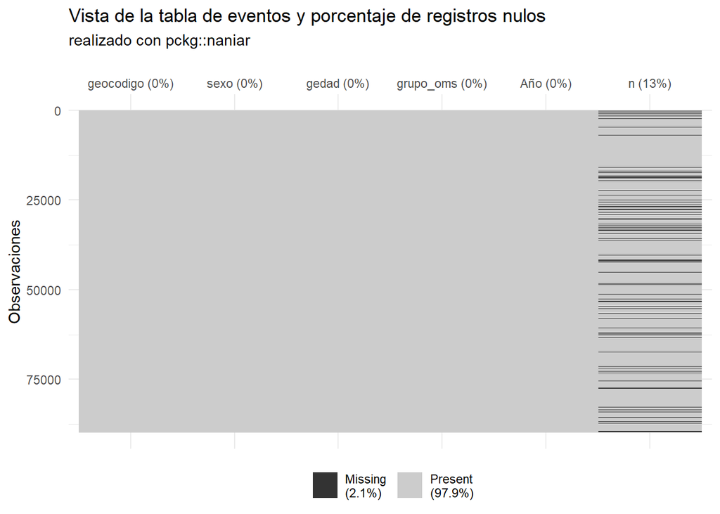

## 2 Los datos de poblacion

Se incorpora datos de poblacion. Los mismos resultan de una interpolacion *spline* de la poblacion en edades simples por sexo a nivel departamental entre las rondas 2001-2010-2022.

```r
glimpse(data_pob)
```

```
## Rows: 67,584
## Columns: 5
## $ geocodigo <dbl> 2000, 2000, 2000, 2000, 2000, 2000, 6007, 6007, 6007, 6007, …
## $ sex       <dbl> 1, 1, 1, 2, 2, 2, 1, 1, 1, 2, 2, 2, 1, 1, 1, 2, 2, 2, 1, 1, …
## $ edad      <chr> "0-24", "25-69", "70 y mas", "0-24", "25-69", "70 y mas", "0…
## $ Year      <dbl> 2001, 2001, 2001, 2001, 2001, 2001, 2001, 2001, 2001, 2001, …
## $ pob_est   <dbl> 441499, 696784, 120175, 442083, 840839, 234758, 3206, 4245, …
```

Se calcula la Tasa Bruta por causa y especifica por edad y sexo segun causa.

```r
glimpse(data_mort)
```

```
## Rows: 89,874
## Columns: 8
## $ geocodigo <chr> "10007", "10007", "10007", "10007", "10007", "10007", "10007…
## $ sexo      <chr> "Mujer", "Mujer", "Mujer", "Mujer", "Mujer", "Mujer", "Mujer…
## $ gedad     <chr> "25 a 69", "25 a 69", "25 a 69", "25 a 69", "25 a 69", "25 a…
## $ grupo_oms <chr> "Condiciones transmisibles, maternas, perinatales y nutricio…
## $ Año       <dbl> 2003, 2006, 2009, 2012, 2015, 2018, 2021, 2003, 2006, 2009, …
## $ n         <int> 2, 2, NA, 1, 2, NA, 3, 1, 2, NA, 1, 2, NA, 1, 5, 6, 12, 11, …
## $ pob_est   <dbl> 941.8519, 979.7407, 1030.9630, 1095.5185, 1173.4074, 1264.62…
## $ tme       <dbl> 212.3, 204.1, NA, 91.3, 170.4, NA, 219.1, 106.2, 204.1, NA, …
```

Aunque por definicion, como los eventos corresponden a una poblacion en riesgo, no pueda ser posible que exista un caso tal que se diera un evento en un año particular y no exista poblacion en ese segmento de edad y sexo.

$$\frac {E} {Pt} = \frac {n}{0} = {Inf}$$

Como es el caso donde se registra un evento de defuncion de varon mayor de 70 y mas en Antartida Argentina, departamento de la Provincia de Tierra de Fuego, cuando no existe poblacion estimada para este segmento. Por tanto la razon `1/0 = Inf`.

```r
knitr::kable(

data_mort |>
  filter(pob_est == 0 , n>0)
)
```

| geocodigo | sexo | gedad | grupo_oms | Año | n | pob_est | tme |
| --- | --- | --- | --- | --- | --- | --- | --- |
| 94028 | Varón | 70 y mas | Enfermedades no transmisibles | 2015 | 1 | 0 | Inf |

Alternativamente los casos donde no existen eventos no son 0 sino Nulos, por tanto se mantendran como Nulos, ya que $\frac {NA}{x_{n}} = NA$

Puede verse una tabla a continuación:

**Click para expandir**

| Año | sexo | gedad | grupo_oms | n | pct_NA |
| --- | --- | --- | --- | --- | --- |
| 2003 | Mujer | 25 a 69 | Condiciones transmisibles, maternas, perinatales y nutricionales | 55 | 10 |
| 2003 | Mujer | 70 y mas | Condiciones transmisibles, maternas, perinatales y nutricionales | 19 | 4 |
| 2003 | Mujer | Menor de 24 | Condiciones transmisibles, maternas, perinatales y nutricionales | 37 | 7 |
| 2003 | Varón | 25 a 69 | Condiciones transmisibles, maternas, perinatales y nutricionales | 13 | 2 |
| 2003 | Varón | 70 y mas | Condiciones transmisibles, maternas, perinatales y nutricionales | 10 | 2 |
| 2003 | Varón | Menor de 24 | Condiciones transmisibles, maternas, perinatales y nutricionales | 26 | 5 |
| 2003 | Mujer | 25 a 69 | Enfermedades mal definidas | 96 | 18 |
| 2003 | Mujer | 70 y mas | Enfermedades mal definidas | 38 | 7 |
| 2003 | Mujer | Menor de 24 | Enfermedades mal definidas | 254 | 47 |
| 2003 | Varón | 25 a 69 | Enfermedades mal definidas | 38 | 7 |

[output cut: 153 more lines]

Al consultar la tabla, por ejemplo, se observa que si se quisiera para todos los años, de mujeres menores de 24 por Condiciones transmisibles, maternas, perinatales y nutricionales, el porcentaje de unidades con areas nulas ronda el entre el 7-16% y es del 22% en el ultimo trienio. Mientras que por causas Mal definidas ronda el 50-60%.

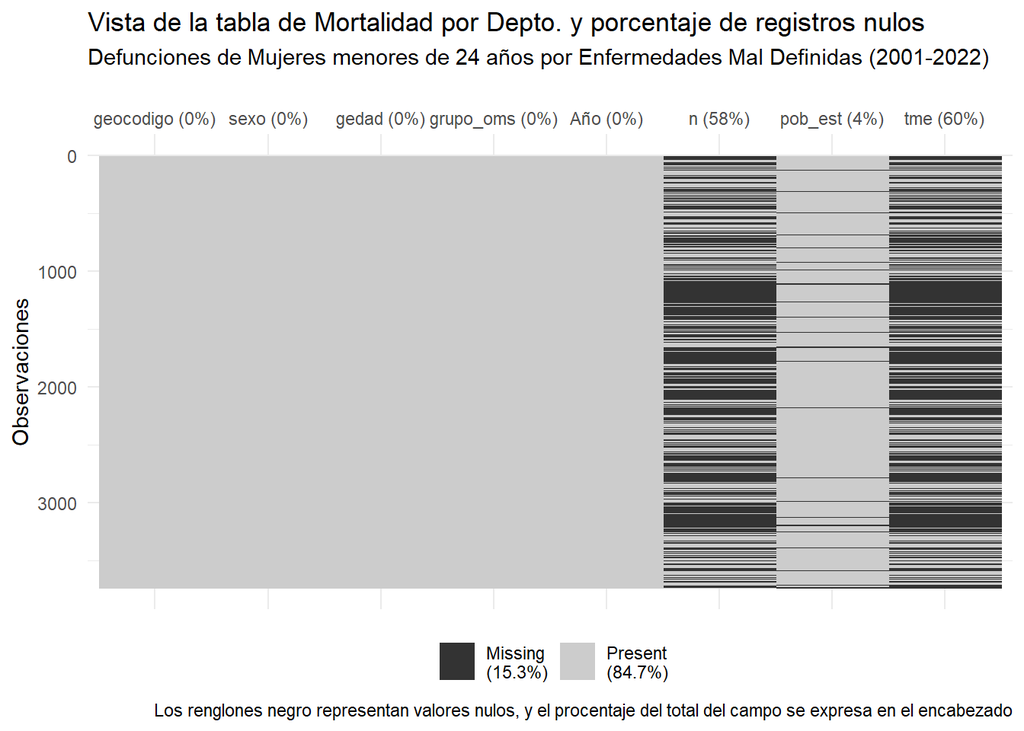

## 3 Resumen de Calculo de Razon

Se puede ver un resumen del conjunto de datos creado

```r
summary(data_mort)
```

```
##   geocodigo             sexo              gedad            grupo_oms
##  Length:89874       Length:89874       Length:89874       Length:89874
##  Class :character   Class :character   Class :character   Class :character
##  Mode  :character   Mode  :character   Mode  :character   Mode  :character
##
##
##
##
##       Año             n               pob_est            tme
##  Min.   :2003   Min.   :    1.00   Min.   :     0   Min.   :   0.7
##  1st Qu.:2006   1st Qu.:    4.00   1st Qu.:  1056   1st Qu.:  90.5
##  Median :2012   Median :   12.00   Median :  3434   Median : 250.5
##  Mean   :2012   Mean   :   91.14   Mean   : 13409   Mean   :   Inf
##  3rd Qu.:2018   3rd Qu.:   43.00   3rd Qu.: 10570   3rd Qu.:1415.9
##  Max.   :2021   Max.   :47875.00   Max.   :986283   Max.   :   Inf
##                 NA's   :11284      NA's   :4032     NA's   :14551
```

Se observa una variablidad extrema donde la `tme` va de 0.7 por 100.000 al Infinito. Si eliminamos el caso problematico:

```r
summary(data_mort_clean)
```

```
##   geocodigo             sexo              gedad            grupo_oms
##  Length:75322       Length:75322       Length:75322       Length:75322
##  Class :character   Class :character   Class :character   Class :character
##  Mode  :character   Mode  :character   Mode  :character   Mode  :character
##
##
##
##       Año             n               pob_est              tme
##  Min.   :2003   Min.   :    1.00   Min.   :     4.4   Min.   :    0.7
##  1st Qu.:2006   1st Qu.:    4.00   1st Qu.:  1230.3   1st Qu.:   90.5
##  Median :2012   Median :   12.00   Median :  4042.7   Median :  250.5
##  Mean   :2012   Mean   :   94.08   Mean   : 14868.6   Mean   : 2135.1
##  3rd Qu.:2018   3rd Qu.:   45.00   3rd Qu.: 12017.8   3rd Qu.: 1415.9
##  Max.   :2021   Max.   :47875.00   Max.   :986283.1   Max.   :53423.0
```

Se observa que existe un problema al lidiar con rangos extremos como los que se observan en casos (`n`) y la poblacion estimada `pob_est`, lo cual se refleja en el rango 0.7 - 53423 de la Razon de Muertes por 100.000

### 3.1 Casos Extremos

#### 3.1.1 Maximos en Razones

Se observa que se deben con frecuencia al tamaño de la poblacion. Donde por ejemplo una tasa de 50.000 por 100.000 resulta de 2 eventos en una poblacion estimada de 4.

| geocodigo | sexo | gedad | grupo_oms | Año | n | pob_est | tme |
| --- | --- | --- | --- | --- | --- | --- | --- |
| 14154 | Varón | 70 y mas | Enfermedades no transmisibles | 2003 | 75 | 140.388889 | 53423.0 |
| 78042 | Varón | 70 y mas | Enfermedades no transmisibles | 2003 | 71 | 152.722222 | 46489.6 |
| 42091 | Mujer | 70 y mas | Enfermedades no transmisibles | 2003 | 2 | 4.351852 | 45957.4 |
| 42063 | Varón | 70 y mas | Enfermedades no transmisibles | 2003 | 11 | 27.370370 | 40189.4 |
| 14154 | Varón | 70 y mas | Enfermedades no transmisibles | 2009 | 63 | 156.793651 | 40180.2 |
| 6770 | Varón | 70 y mas | Enfermedades no transmisibles | 2003 | 593 | 1508.500000 | 39310.6 |
| 10014 | Varón | 70 y mas | Enfermedades no transmisibles | 2003 | 28 | 72.555556 | 38591.1 |
| 6070 | Varón | 70 y mas | Enfermedades no transmisibles | 2003 | 364 | 959.611111 | 37932.0 |
| 30042 | Varón | 70 y mas | Enfermedades no transmisibles | 2003 | 92 | 244.740741 | 37590.8 |
| 10077 | Varón | 70 y mas | Enfermedades no transmisibles | 2003 | 43 | 116.407407 | 36939.2 |

#### 3.1.2 Minimos en Razones

Mientras que las tasas en extremo bajas, corresponden con casos de muy baja frecuencia de eventos.

| geocodigo | sexo | gedad | grupo_oms | Año | n | pob_est | tme |
| --- | --- | --- | --- | --- | --- | --- | --- |
| 2000 | Mujer | Menor de 24 | Enfermedades mal definidas | 2012 | 3 | 431536.18 | 0.7 |
| 66028 | Mujer | Menor de 24 | Enfermedades mal definidas | 2012 | 1 | 123909.31 | 0.8 |
| 66028 | Varón | Menor de 24 | Enfermedades mal definidas | 2015 | 1 | 126014.11 | 0.8 |
| 90084 | Mujer | Menor de 24 | Enfermedades mal definidas | 2015 | 1 | 114100.35 | 0.9 |
| 90084 | Varón | Menor de 24 | Enfermedades mal definidas | 2018 | 1 | 111180.06 | 0.9 |
| 6805 | Varón | Menor de 24 | Enfermedades mal definidas | 2018 | 1 | 88364.91 | 1.1 |
| 58035 | Varón | Menor de 24 | Enfermedades mal definidas | 2012 | 1 | 81597.89 | 1.2 |
| 6805 | Mujer | Menor de 24 | Enfermedades mal definidas | 2021 | 1 | 84646.40 | 1.2 |
| 54028 | Mujer | Menor de 24 | Enfermedades mal definidas | 2015 | 1 | 79602.67 | 1.3 |
| 54028 | Varón | Menor de 24 | Enfermedades mal definidas | 2018 | 1 | 78994.66 | 1.3 |
| 54028 | Varón | Menor de 24 | Enfermedades mal definidas | 2021 | 1 | 79278.88 | 1.3 |
| 58035 | Mujer | Menor de 24 | Enfermedades mal definidas | 2003 | 1 | 77002.31 | 1.3 |
| 58035 | Mujer | Menor de 24 | Enfermedades mal definidas | 2006 | 1 | 76894.64 | 1.3 |
| 58035 | Mujer | Menor de 24 | Enfermedades mal definidas | 2009 | 1 | 77243.99 | 1.3 |
| 58035 | Mujer | Menor de 24 | Enfermedades mal definidas | 2015 | 1 | 79313.76 | 1.3 |
| 58035 | Varón | Menor de 24 | Enfermedades mal definidas | 2003 | 1 | 79252.80 | 1.3 |

### 3.2 Reflexiones parciales

Se ha creado un conjunto de datos para el analisis, resto recuperar evitando redundancia los nombres de departamento y provincia, asi como la region.

```r
glimpse(data_mort_clean)
```

```
## Rows: 75,322
## Columns: 8
## $ geocodigo <chr> "10007", "10007", "10007", "10007", "10007", "10007", "10007…
## $ sexo      <chr> "Mujer", "Mujer", "Mujer", "Mujer", "Mujer", "Mujer", "Mujer…
## $ gedad     <chr> "25 a 69", "25 a 69", "25 a 69", "25 a 69", "25 a 69", "25 a…
## $ grupo_oms <chr> "Condiciones transmisibles, maternas, perinatales y nutricio…
## $ Año       <dbl> 2003, 2006, 2012, 2015, 2021, 2003, 2006, 2012, 2015, 2021, …
## $ n         <int> 2, 2, 1, 2, 3, 1, 2, 1, 2, 1, 5, 6, 12, 11, 10, 8, 12, 1, 2,…
## $ pob_est   <dbl> 941.8519, 979.7407, 1095.5185, 1173.4074, 1369.1852, 941.851…
## $ tme       <dbl> 212.3, 204.1, 91.3, 170.4, 219.1, 106.2, 204.1, 91.3, 170.4,…
```

El análisis de la mortalidad por causas según edad y sexo a nivel DAME, enfrenta ciertas limitaciones. En primer lugar Los valores extremos se hallan derivados de:

Por un lado, la **baja frecuencia de población** favorece razones (y no tasas) muy elevadas, sobre todo cuando existen causas y grupos de edad con alta mortalidad, como las edades avanzadas y enfermedades crónicas ( ~ 30.000 a 50.000 por c/100.000). Por otro lado, **la baja frecuencia en eventos**, por causas poco comunes en segmentos de edad grandes, como por ejemplo las defunciones debidas a Enfermedades Mal definidas en edades jóvenes o menores de 24 años, conducen a razones en extremo bajas ( ~ 1 a 3 por c/100.000)  
Por último, también sucede que pueden darse casos de defunciones en ciertos segmentos de edad y sexo, para el cual no existe un denominador (en este ejercicio solo un caso) o **no hay poblacion**. Mientras que alternativamente, sucede más frecuente, que **no ocurran eventos** por ciertas causas, en segmentos por edad y sexo, que conducen a razones o tasas Nulas. Esto no indicaría el *riesgo cero* de fallecer por determinada causa en un grupo de edad y sexo en un área determinada, ya que se debe antes, a la aleatoriedad debida al tamaño de la población, el área, y las características del sistema de clasificación de causas de defunción. El caso se da por ejemplo en las defunciones por Enfermedades mal definidas en mujeres jóvenes donde para casi toda la serie está ausente en al rededor del 50 al 60% de las unidades de área.

En segundo lugar, puede considerarse las complicaciones derivadas de la definicion de la unidad de area. Por un lado estan sometidasa cambios lo cual puede complicar el analisis a lo largo del tiempo. Por otro lado, los criterios que determinan la forma general son arbitrarios, por lo que se observa una gran heterogeneidad de tamaño y composicion.

Al aumentar la escala al nivel jurisdiccional y regional, la frecuencia de casos así como la estabilidad en las unidades de area, permite conducir analisis comparativos geograficos y en el tiempo, pero se reduce el poder explicativo y la posibilidad de detectar la heterogeneidad *detras de los modelos* y sobre esto se cetrará el analisis en los capitulos siguientes.

En adelante:

Comparaciones.

Evolucion temporal.

Distribucion espacial.